# Directions for Calculating the Chessie BIBI in RStudio

**INTRODUCTION**  
This R-script and documentation is intended as a supplement to the [Smith et al. (2017) final report](https://www.potomacriver.org/wp-content/uploads/2017/05/ChessieBIBI_Report_Final_5-25-2017.pdf) and [appendices](https://www.potomacriver.org/wp-content/uploads/2017/05/ChessieBIBI_Appendix_Final_5-25-2017.pdf). Use the following scripts to calculate the family-and bioregion- level “Chessie BIBI,” or Chesapeake Basin-wide Index of Biotic Integrity for streams and wadeable rivers in the Chesapeake Bay watershed.

**BEFORE YOU GET STARTED** In order to implement the following R scripts, RStudio must be installed. If RStudio is not installed, it can be downloaded for free from https://www.rstudio.com/. This [webpage](https://courses.edx.org/courses/UTAustinX/UT.7.01x/3T2014/56c5437b88fa43cf828bff5371c6a924/) will help guide you through the short installation process. Once installed, or if already installed, the scripts are designed to be copied and pasted into RStudio. Currently, a Windows machine must be used for data importation. For those unfamiliar with RStudio, each time a dataframe is created, it can be viewed by typing in `View(name)` in the console or by clicking its name in the Environment tab on the right.

**1. DATA PREPARATION**  
Most macroinvertebrate assemblage data are formatted in a similar manner; however, rarely can data sets from two separate entities be joined without some manipulation. The data preparation functions outlined below manipulate the data to meet formatting requirements necessary for using the contained custom functions in the *bibi2.0* and *mmir* packages. For any of the functions to be useful, the user must first prepare their data using the provided functions outlined below.

The [Integrated Taxonomic Information System (ITIS)](https://www.itis.gov/) is an online database managed by federal agencies that attempts to provide the current taxonomic nomenclature. The Taxonomic Serial Number (TSN), a unique identification number assigned to each taxon, was also adopted from ITIS.gov. If the taxon was not found in ITIS but was valid based on a review of the literature, the taxon was assigned a unique negative integer. The negative integers will never overlap with the positive integers used by ITIS, allowing the table to accommodate additional taxa from ITIS without issue. The TSNs are reflected in the *TSN_FINAL* column in the Master Taxa List. It must also include a *FINAL_ID* column indicating the lowest taxonomic rank represented in a given row. Additionally, the Master Taxa List must contain each of the following taxonomic ranks: Phylum, Subphylum, Class, Subclass, Order, Suborder, Family, Subfamily, Tribe, Genus, Species. Finally, if the user wants to calculate any of the metrics related to these taxonomic attributes, the table must also contain contain Tolerance Values (TV), Functional Feeding Groups (FFG), Habits, and Beck’s Class.

**1.1** Set the working directory to a location where the scripts can be saved using `setwd("")"`. Don’t forget to use a forward slash `/` instead of a backward slash `\` in the path name.

Load the following packages into the environment. The packages must be installed before they can be opened. To install a package, use `install.packages(" ")`, then open with `library()`.

*mmir* is a custom package developed by Zachary Smith to calculate taxonomic community metrics. The development version can be downloaded from the [ICPRB GitHub account](https://github.com/InterstateCommissionPotomacRiverBasin/mmir) using `devtools::install_github(repo = "InterstateCommissionPotomacRiverBasin/mmir")`. After the installation, *mmir* must be loaded into the environment using `library()`.

```r
library(tidyverse)
library(stringr)
library(lubridate)
library(mmir)
library(bibi2.0) # Build in R Studio
library(odbc) # For Windows 64-bit; see 1.2
library(RODBC) # For Windows 32-bit; see 1.2
library(DBI)
library(magrittr)
library(vegan)
library(ggplot2)
```

**1.2** Import the following tables from the Microsoft Access database. This process differs depending on which version of Windows, 64-bit or 32-bit, is installed. Both directions are outlined below.

Windows 64-bit:

```r
channel <- dbConnect(odbc(), "CBIBI_2017")
tab.vec <- c("TAB_EVENT",
             "TAB_STATIONS",
             "TAB_PROJECT",
             "TAB_WQ_DATA",
             "TAB_PARAMETER_WQ",
             "TAB_HABITAT_ASSESSMENT",
             "TAB_HABITAT_PARAMETERS",
             "TAB_TAXONOMIC_COUNT",
             "TAB_HUC_12",
             "TAB_PROGRAM",
             "TAB_MASTER_TAXA_LIST")
 tab.list <- purrr::map(tab.vec, function(tab.i) {
  dbReadTable(channel, tab.i, stringsAsFactors = FALSE) %>%
    clean_data_frame()
}) %>%
  set_names(tolower(tab.vec))
dbDisconnect(channel)
```

Windows 32-bit:

```r
channel <- RODBC::odbcConnect("CBIBI_2017")

tab.vec <- c("TAB_EVENT",
             "TAB_STATIONS",
             "TAB_PROJECT",
             "TAB_WQ_DATA",
             "TAB_PARAMETER_WQ",
             "TAB_HABITAT_ASSESSMENT",
             "TAB_HABITAT_PARAMETERS",
             "TAB_TAXONOMIC_COUNT",
             "TAB_HUC_12",
             "TAB_PROGRAM",
             "TAB_MASTER_TAXA_LIST")

 tab.list <- purrr::map(tab.vec, function(tab.i) {
  RODBC::sqlFetch(channel, tab.i, stringsAsFactors = FALSE) %>%
    clean_df()
}) %>%
  set_names(tolower(tab.vec))

RODBC::odbcCloseAll()
```

**1.3** Join the Master Taxa List to the taxonomic count table using the *tsn_final* column. Then, apply the `prep_taxa()` function in the *bibi2.0* package to perform taxa eclusions and roll-ups (Final Report, Pages 6-7).

```r
 tab.list$tab_taxonomic_count <- tab.list$tab_taxonomic_count %>%
   dplyr::mutate(tsn_final = str_replace_all(tsn_final, "(?<![0-9])0+", "")) %>%
   left_join(tab.list$tab_master_taxa_list, by = "tsn_final") %>%
   prep_taxa()
```

**1.4** Apply the `prep_data()` function from the *bibi2.0* package to the indicated tables. Several prepping functions are nested within `prep_data()`:

1. Water quality: select only specific conductivity, dissolved oxygen, and pH;
2. Habitat: select only epifaunal substrate, bank stability, embeddedness, channel alteration, riffle/run/pool/ ratio, flow, bank vegetation, and sedimentation, then calculate habitat conditions;
3. Method: exclude samples collected from December to February; include only samples from 1<sup>st</sup> - 4<sup>th</sup> order streams; restrict the sampling method to kick-net or similar procedures.

The output is **prep.df**, one large data frame which contains all of the taxa, water quality, and habitat data.

```r
prep.df <- prep_data(tab.list$tab_taxonomic_count,
                     tab.list$tab_wq_data,
                     tab.list$tab_habitat_assessment,
                     tab.list$tab_event,
                     tab.list$tab_stations,
                     tab.list$tab_project,
                     tab.list$tab_huc_12,
                     agg_sample_num = TRUE,
                     development = FALSE) # Should this be set to false?
rm(tab.list)
```

**1.5** Convert the Functional Feeding Group (ffg) and Habit abbreviations to full names. This adds two new columns, *ffg* and *habit*, to **prep.df2**, which will be used instead of *bibi_ffg* and *bibi_habit*.

```r
prep.df2 <-
    dplyr::mutate(prep.df, ffg = case_when(
    is.na(bibi_ffg) | bibi_ffg == "" ~ as.character(NA),
    bibi_ffg == "cg" ~ "gather",
    bibi_ffg == "pr" ~ "predator",
    bibi_ffg == "sc" ~ "scrape",
    bibi_ffg == "cf" ~ "filter",
    bibi_ffg == "sh" ~ "shred",
    bibi_ffg == "om" ~ "omnivore",
    bibi_ffg == "pa" ~ "parasite",
    bibi_ffg %in% c("pc", "pi") ~ "pierce",
    TRUE ~ "ERROR"
  ),
  habit = case_when(
    is.na(bibi_habit) | bibi_habit == "" ~ as.character(NA),
    bibi_habit == "sp" ~ "sprawl",
    bibi_habit == "cn" ~ "cling",
    bibi_habit == "cb" ~ "climb",
    bibi_habit == "bu" ~ "burrow",
    bibi_habit == "sw" ~ "swim",
    bibi_habit == "sk" ~ "skate",
    TRUE ~ "ERROR"
  )
)
```

**1.6** Perform general cleaning of the data frame, and select out only the indicated columns. The resulting data frame is **taxa.df**, which will be the input to the rarefaction step.

```r
taxa.df <- prep.df2 %>%
  ungroup() %>%
  select(unique_id, icprb_bioregion_id, reporting_value,
         final_id,
         phylum, subphylum, class, subclass,
         order, suborder, family, subfamily, tribe, genus, habit, ffg, bibi_tv) %>%
  group_by_at(vars(-reporting_value)) %>%
  summarize(reporting_value = sum(reporting_value)) %>%
  ungroup() %>%
  fill_taxa(final_id, phylum:genus) %>%
  mutate(final_id = genus) %>%
  group_by_at(vars(-reporting_value)) %>%
  summarize(reporting_value = sum(reporting_value)) %>%
  ungroup()
```

**1.7** Probabilistic rarefaction as described in Appendix D.

```r
taxa.df <- prob_rarefaction(taxa.df, unique_id, reporting_value, genus, 100)
```

**2. CALCULATE THE BIOLOGICAL METRICS**  
Now that the data are in the proper format and the samples have been rarefied, the biological metrics can be calcualted using *mmir*. To streamline this process, all of the metrics are computed for each unique_id. Later on, metrics specific to each bioregion will be selected out.

The first step is to generate a new data frame for the non-rarefied and rarefied data, both of which are needed as some metrics require rarefied data, but thers do not.

Next, a data frame, **metrics.key**, will be generated. **metrics.key** initially only contains the following columns: unique_id, icprb_bioregion_id, event_latitude, event_longitude, and huc_12, but each calculated metric is appended.

```r
# Create a data frame of the non-rarefied and rarefied data.
non_rare <- prep.df2 %>%
   arrange(unique_id) %>%
   ungroup()

rare <- taxa.df %>%
   arrange(unique_id) %>%
   ungroup()

# Create the metrics.key data frame.
 metrics.key <- non_rare %>%
  select(unique_id, icprb_bioregion_id, event_latitude, event_longitude, huc_12) %>%
  unique() %>%
  arrange(unique_id)

# Calculate the metrics. Use long.df to specify which data frame to use (non-rarefied or rarefied. First, the non-rarefied data will be used.)
  metrics.key$aspt_mod <- taxa_tol_index(
  long.df = non_rare,
  unique.id.col = unique_id,
  count.col = reporting_value,
  tol.col = aspt)

  metrics.key$pct_gastro_oligo <- taxa_pct(
  long.df = non_rare,
  unique.id.col = unique_id,
  count.col = reporting_value,
  taxon.col = class,
  taxon = c("gastropoda", "oligochatea"))

  metrics.key$pct_diptera <- taxa_pct(
  long.df = non_rare,
  unique.id.col = unique_id,
  count.col = reporting_value,
  taxon.col = order,
  taxon = "diptera")

  metrics.key$gold <- 100 - (metrics.key$pct_gastro_oligo + metrics.key$pct_diptera)

  metrics.key$hbi <- taxa_tol_index(
  long.df = non_rare,
  unique.id.col = unique_id,
  count.col = reporting_value,
  tol.col = bibi_tv)

  metrics.key$pct_arthropoda <- taxa_pct(
  long.df = non_rare,
  unique.id.col = unique_id,
  count.col = reporting_value,
  taxon.col = phylum,
  taxon = "arthropoda")

  metrics.key$pct_burrow <- taxa_pct(
  long.df = non_rare,
  unique.id.col = unique_id,
  count.col = reporting_value,
  taxon.col = habit,
  taxon = "burrow")

  metrics.key$pct_chironomidae <- taxa_pct(
  long.df = non_rare,
  unique.id.col = unique_id,
  count.col = reporting_value,
  taxon.col = family,
  taxon = "chironomidae")

  metrics.key$pct_cling <- taxa_pct(
  long.df = non_rare,
  unique.id.col = unique_id,
  count.col = reporting_value,
  taxon.col = habit,
  taxon = "cling")

  metrics.key$pct_burrow <- taxa_pct(
  long.df = non_rare,
  unique.id.col = unique_id,
  count.col = reporting_value,
  taxon.col = habit,
  taxon = "burrow")

  metrics.key$pct_collect <- taxa_pct(
  long.df = non_rare,
  unique.id.col = unique_id,
  count.col = reporting_value,
  taxon.col = ffg,
  taxon = c("filter", "gather"))

  metrics.key$pct_cote <- taxa_pct(
  long.df = non_rare,
  unique.id.col = unique_id,
  count.col = reporting_value,
  taxon.col = order,
  taxon = c("coleoptera",
            "odonata",
            "trichoptera",
            "ephemeroptera"))

  metrics.key$pct_ephemeroptera <- taxa_pct(
  long.df = non_rare,
  unique.id.col = unique_id,
  count.col = reporting_value,
  taxon.col = order,
  taxon = "ephemeroptera")

  metrics.key$pct_baetidae <- taxa_pct(
  long.df = non_rare,
  unique.id.col = unique_id,
  count.col = reporting_value,
  taxon.col = family,
  taxon = "baetidae")

  metrics.key$pct_ephemeroptera_no_baetid <- metrics.key$pct_ephemeroptera - metrics.key$pct_baetidae

  metrics.key$pct_ept <- taxa_pct(
  long.df = non_rare,
  unique.id.col = unique_id,
  count.col = reporting_value,
  taxon.col = order,
  taxon = c("ephemeroptera",
            "plecoptera",
            "trichoptera"))

  metrics.key$pct_hydropsychidae <- taxa_pct(
  long.df = non_rare,
  unique.id.col = unique_id,
  count.col = reporting_value,
  taxon.col = family,
  taxon = "hydropsychidae")

  metrics.key$pct_ept_no_hydro <- metrics.key$pct_ept - metrics.key$pct_hydropsychidae

  metrics.key$pct_euholognatha <- taxa_pct(
  long.df = non_rare,
  unique.id.col = unique_id,
  count.col = reporting_value,
  taxon.col = suborder,
  taxon = "euholognatha")

  metrics.key$pct_filter <- taxa_pct(
  long.df = non_rare,
  unique.id.col = unique_id,
  count.col = reporting_value,
  taxon.col = ffg,
  taxon = "filter")

  metrics.key$pct_heptageniidae <- taxa_pct(
  long.df = non_rare,
  unique.id.col = unique_id,
  count.col = reporting_value,
  taxon.col = family,
  taxon = "heptageniidae")

  metrics.key$pct_hexapoda <- taxa_pct(
  long.df = non_rare,
  unique.id.col = unique_id,
  count.col = reporting_value,
  taxon.col = subphylum,
  taxon = "hexapoda")

  metrics.key$pct_hydro_ept <- ifelse(metrics.key$pct_ept == 0, 0, (metrics.key$pct_hydropsychidae / metrics.key$pct_ept) * 100)

  metrics.key$pct_intol_0_3 <- taxa_pct(
  long.df = non_rare,
  unique.id.col = unique_id,
  count.col = reporting_value,
  taxon.col = bibi_tv,
  taxon = 0:3)

  metrics.key$pct_intol_0_4 <- taxa_pct(
  long.df = non_rare,
  unique.id.col = unique_id,
  count.col = reporting_value,
  taxon.col = bibi_tv,
  taxon = 0:4)

  metrics.key$pct_amph_iso <- taxa_pct(
  long.df = non_rare,
  unique.id.col = unique_id,
  count.col = reporting_value,
  taxon.col = order,
  taxon = c("amphipoda", "isopoda"))

  metrics.key$pct_ephemerellidae <- taxa_pct(
  long.df = non_rare,
  unique.id.col = unique_id,
  count.col = reporting_value,
  taxon.col = family,
  taxon = "ephemerellidae")

  metrics.key$pct_limestone <- metrics.key$pct_amph_iso + metrics.key$pct_ephemerellidae

  metrics.key$pct_mod_tol_4_6 <- taxa_pct(
  long.df = non_rare,
  unique.id.col = unique_id,
  count.col = reporting_value,
  taxon.col = bibi_tv,
  taxon = 4:6)

  metrics.key$pct_trichoptera <- taxa_pct(
  long.df = non_rare,
  unique.id.col = unique_id,
  count.col = reporting_value,
  taxon.col = order,
  taxon = "trichoptera")

  metrics.key$pct_non_hydrop_trichoptera <- metrics.key$pct_trichoptera - metrics.key$pct_hydropsychidae

  metrics.key$pct_odonata <- taxa_pct(
  long.df = non_rare,
  unique.id.col = unique_id,
  count.col = reporting_value,
  taxon.col = order,
  taxon = "odonata")

  metrics.key$pct_pisciforma <- taxa_pct(
  long.df = non_rare,
  unique.id.col = unique_id,
  count.col = reporting_value,
  taxon.col = suborder,
  taxon = "pisciforma")

  metrics.key$pct_predator <- taxa_pct(
  long.df = non_rare,
  unique.id.col = unique_id,
  count.col = reporting_value,
  taxon.col = ffg,
  taxon = "predator")

  metrics.key$pct_pterygota <- taxa_pct(
  long.df = non_rare,
  unique.id.col = unique_id,
  count.col = reporting_value,
  taxon.col = subclass,
  taxon = "pterygota")

  metrics.key$pct_retreat_caddisfly <- taxa_pct(
  long.df = non_rare,
  unique.id.col = unique_id,
  count.col = reporting_value,
  taxon.col = suborder,
  taxon = "annulipalpia")

  metrics.key$pct_scrape = taxa_pct(
  long.df = non_rare,
  unique.id.col = unique_id,
  count.col = reporting_value,
  taxon.col = ffg,
  taxon = "scrape")

  metrics.key$pct_sprawl <- taxa_pct(
  long.df = non_rare,
  unique.id.col = unique_id,
  count.col = reporting_value,
  taxon.col = habit,
  taxon = "sprawl")

  metrics.key$pct_systellognatha <- taxa_pct(
  long.df = non_rare,
  unique.id.col = unique_id,
  count.col = reporting_value,
  taxon.col = suborder,
  taxon = "systellognatha")

  metrics.key$pct_tolerant_7_10 <- taxa_pct(
  long.df = non_rare,
  unique.id.col = unique_id,
  count.col = reporting_value,
  taxon.col = bibi_tv,
  taxon = 7:10)

  metrics.key$pct_urban_intol <- taxa_pct(
  long.df = non_rare,
  unique.id.col = unique_id,
  count.col = reporting_value,
  taxon.col = family,
  taxon = c(
    "aeshnidae",
    "ameletidae",
    "asellidae",
    "athericidae",
    "baetidae",
    "brachycentridae",
    "caenidae",
    "calamoceratidae",
    "cambaridae",
    "capniidae",
    "ceratopogonidae",
    "chironomidae",
    "chloroperlidae",
    "cordulegastridae",
    "corduliidae",
    "corydalidae",
    "crangonyctidae",
    "elmidae",
    "ephemerellidae",
    "ephemeridae",
    "glossosomatidae",
    "gomphidae",
    "heptageniidae",
    "hydropsychidae",
    "hydroptilidae",
    "isonychiidae",
    "lepidostomatidae",
    "leptophlebiidae",
    "leuctridae",
    "libellulidae",
    "metretopodidae",
    "nemouridae",
    "odontoceridae",
    "peltoperlidae",
    "perlidae",
    "perlodidae",
    "philopotamidae",
    "phryganeidae",
    "polycentropodidae",
    "polymitarcyidae",
    "potamanthidae",
    "psephenidae",
    "pteronarcyidae",
    "rhyacophilidae",
    "sericostomatidae",
    "sialidae",
    "simuliidae",
    "stratiomyidae",
    "tabanidae",
    "taeniopterygidae",
    "tipulidae",
    "uenoidae",
    "viviparidae"))

# Richness/Diversity metrics require rarefied data, so switch the long.df from non_rare to rare.

  metrics.key$margalefs = taxa_div(
  long.df = rare,
  unique.id.col = unique_id,
  count.col = rare_count,
  high.taxa.col = family,
  job = "margalef")

  taxa_count <- rare %>%
    group_by(unique_id) %>%
     filter(!is.na(bibi_tv)) %>%
      count(unique_id)
    ept_count <- rare %>%
      group_by(unique_id) %>%
       filter(!is.na(bibi_tv)) %>%
        tally(order %in% c("ephemeroptera", "plecoptera", "trichoptera"))
    metrics.key$pct_ept_rich <- (ept_count$n / taxa_count$n)*100

  ept_no_tol_count <- rare %>%
    group_by(unique_id) %>%
     filter(!is.na(bibi_tv)) %>%
      tally(order %in% c("ephemeroptera", "plecoptera", "trichoptera") & bibi_tv %in% c("0","1","2","3","4","5","6"))
    metrics.key$pct_ept_rich_no_tol <- (ept_no_tol_count$n/taxa_count$n)*100

  metrics.key$pielou <- taxa_div(
  long.df = rare,
  unique.id.col = unique_id,
  count.col = rare_count,
  high.taxa.col = family,
  job = "pielou")

  metrics.key$rich_burrow <- taxa_rich(
  long.df = rare,
  unique.id.col = unique_id,
  low.taxa.col = habit,
  high.taxa.col = family,
  taxon = "burrow")

  metrics.key$rich_climb <- taxa_rich(
  long.df = rare,
  unique.id.col = unique_id,
  low.taxa.col = habit,
  high.taxa.col = family,
  taxon = "climb")

  metrics.key$rich_cling <- taxa_rich(
  long.df = rare,
  unique.id.col = unique_id,
  low.taxa.col = habit,
  high.taxa.col = family,
  taxon = "cling")

  metrics.key$rich_collect <- taxa_rich(
  long.df = rare,
  unique.id.col = unique_id,
  low.taxa.col = ffg,
  high.taxa.col = family,
  taxon = c("filter", "gather"))

  metrics.key$rich_ephemeroptera <- taxa_rich(
  long.df = rare,
  unique.id.col = unique_id,
  low.taxa.col = order,
  high.taxa.col = family,
  taxon = "ephemeroptera")

  metrics.key$rich_ept <- taxa_rich(
  long.df = rare,
  unique.id.col = unique_id,
  low.taxa.col = order,
  high.taxa.col = family,
  taxon = c("ephemeroptera", "plecoptera", "trichoptera"))

  metrics.key$rich_filter <- taxa_rich(
  long.df = rare,
  unique.id.col = unique_id,
  low.taxa.col = ffg,
  high.taxa.col = family,
  taxon = "filter")

  metrics.key$rich_gather <- taxa_rich(
  long.df = rare,
  unique.id.col = unique_id,
  low.taxa.col = ffg,
  high.taxa.col = family,
  taxon = "gather")

  metrics.key$rich_intol <- taxa_rich(
  long.df = rare,
  unique.id.col = unique_id,
  low.taxa.col = bibi_tv,
  high.taxa.col = family,
  taxon = 0:3)

  metrics.key$rich_modtol <- taxa_rich(
  long.df = rare,
  unique.id.col = unique_id,
  low.taxa.col = bibi_tv,
  high.taxa.col = family,
  taxon = 4:6)

  metrics.key$rich_plecoptera <- taxa_rich(
  long.df = rare,
  unique.id.col = unique_id,
  low.taxa.col = order,
  high.taxa.col = family,
  taxon = "plecoptera")

  metrics.key$rich_predator <- taxa_rich(
  long.df = rare,
  unique.id.col = unique_id,
  low.taxa.col = ffg,
  high.taxa.col = family,
  taxon = "predator")

  metrics.key$rich_shred <- taxa_rich(
  long.df = rare,
  unique.id.col = unique_id,
  low.taxa.col = ffg,
  high.taxa.col = family,
  taxon = "shred")

  metrics.key$rich_sprawl <- taxa_rich(
  long.df = rare,
  unique.id.col = unique_id,
  low.taxa.col = habit,
  high.taxa.col = family,
  taxon = "sprawl")

  metrics.key$rich_tol <- taxa_rich(
  long.df = rare,
  unique.id.col = unique_id,
  low.taxa.col = bibi_tv,
  high.taxa.col = family,
  taxon = 7:10)

  metrics.key$rich_trichoptera <- taxa_rich(
  long.df = rare,
  unique.id.col = unique_id,
  low.taxa.col = order,
  high.taxa.col = family,
  taxon = "trichoptera")

print(metrics.key)
```

**3. METRIC SCORING**  
**3.1** Subset **metrics.key** by bioregion, creating a new data frame for each of the twelve bioregions.

```r
NAPU <- metrics.key %>% filter(icprb_bioregion_id == "napu")
NCA <- metrics.key %>% filter(icprb_bioregion_id == "nca")
CA <- metrics.key %>% filter(icprb_bioregion_id == "ca")
MAC<- metrics.key %>% filter(icprb_bioregion_id == "mac")
SEP <- metrics.key %>% filter(icprb_bioregion_id == "sep")
BLUE <- metrics.key %>% filter(icprb_bioregion_id == "blue")
NRV <- metrics.key %>% filter(icprb_bioregion_id == "nrv")
SRV <- metrics.key %>% filter(icprb_bioregion_id == "srv")
UNP <- metrics.key %>% filter(icprb_bioregion_id == "unp")
SGV <- metrics.key %>% filter(icprb_bioregion_id == "sgv")
LNP <- metrics.key %>% filter(icprb_bioregion_id == "lnp")
PIED <- metrics.key %>% filter(icprb_bioregion_id == "pied")
```

**3.2** Create a data frame that contains the metrics specific to each of the twelve bioregions. A list of the metrics in each bioregion can be found in Table 15, Page 44 of the Final Report. One change has been made from the original list of metrics: pct_predator was removed from NAPU, as it was deemed unnecessary.

```r
#Northern Appalachian Plateau and Uplands (NAPU)
NAPU_score <- NAPU %>%
  select(
  "unique_id",
  "event_latitude",
  "event_longitude",
  "huc_12",
  "icprb_bioregion_id",
  "margalefs",
  "pct_cling",
  "pct_collect",
  "pct_ephemeroptera",
  "pct_ept",
  "pct_ept_no_hydro",
  "pct_ept_rich_no_tol",
  "pct_filter",
  "pct_intol_0_3",
  "pct_non_hydrop_trichoptera",
  "pct_scrape",
  "pielou",
  "rich_burrow",
  "rich_cling",
  "rich_gather",
  "rich_modtol",
  "rich_plecoptera",
  "rich_shred",
  "rich_sprawl")

# North Central Appalachians (NCA)
NCA_score <- NCA %>%
  select(
    "unique_id",
    "event_latitude",
    "event_longitude",
    "huc_12",
    "icprb_bioregion_id",
    "aspt_mod",
    "pct_cote",
    "pct_ephemeroptera",
    "pct_heptageniidae",
    "pct_limestone",
    "rich_cling",
    "rich_ephemeroptera",
    "rich_ept",
    "rich_plecoptera")
# Central Appalachians (CA)
CA_score <- CA %>%
  select(
    "unique_id",
    "event_latitude",
    "event_longitude",
    "huc_12",
    "icprb_bioregion_id",
    "pct_ept_rich",
    "pct_euholognatha",
    "pct_heptageniidae",
    "pct_hydro_ept",
    "pct_mod_tol_4_6",
    "pct_non_hydrop_trichoptera",
    "pct_pisciforma",
    "pct_systellognatha",
    "rich_burrow",
    "rich_collect",
    "rich_filter",
    "rich_plecoptera",
    "rich_predator")
# Middle Atlantic Coastal Plain (MAC)
MAC_score <- MAC %>%
  select(
    "unique_id",
    "event_latitude",
    "event_longitude",
    "huc_12",
    "icprb_bioregion_id",
    "aspt_mod",
    "gold",
    "pct_arthropoda",
    "pct_chironomidae",
    "pct_collect",
    "pct_mod_tol_4_6",
    "pct_odonata",
    "pct_predator",
    "pct_scrape",
    "pct_urban_intol",
    "rich_climb",
    "rich_tol")
# Southeastern Plains (SEP)
SEP_score <- SEP %>%
  select(
    "unique_id",
    "event_latitude",
    "event_longitude",
    "huc_12",
    "icprb_bioregion_id",
    "aspt_mod",
    "gold",
    "hbi",
    "pct_cling",
    "pct_cote",
    "pct_ept_rich_no_tol",
    "rich_cling",
    "rich_collect",
    "rich_ephemeroptera",
    "rich_filter",
    "rich_trichoptera")
# Blue Ridge (BLUE)
BLUE_score <- BLUE %>%
  select(
    "unique_id",
    "event_latitude",
    "event_longitude",
    "huc_12",
    "icprb_bioregion_id",
    "pct_burrow",
    "pct_ept_rich_no_tol",
    "pct_scrape",
    "pct_systellognatha",
    "rich_ephemeroptera")
# Northern Ridge and Valley (NRV)
NRV_score <- NRV %>%
  select(
    "unique_id",
    "event_latitude",
    "event_longitude",
    "huc_12",
    "icprb_bioregion_id",
    "aspt_mod",
    "pct_ephemeroptera_no_baetid",
    "pct_ept_rich",
    "rich_collect",
    "rich_ephemeroptera",
    "rich_predator",
    "rich_shred",
    "rich_trichoptera")
# Southern Ridge and Valley (SRV)
SRV_score <- SRV %>%
  select(
    "unique_id",
    "event_latitude",
    "event_longitude",
    "huc_12",
    "icprb_bioregion_id",
    "aspt_mod",
    "pct_burrow",
    "pct_cling",
    "pct_cote",
    "pct_ephemeroptera_no_baetid",
    "pct_ept_rich_no_tol",
    "pct_predator",
    "pct_scrape",
    "rich_cling",
    "rich_collect",
    "rich_ephemeroptera",
    "rich_intol",
    "rich_plecoptera",
    "rich_predator",
    "rich_trichoptera")
# Upper Northern Piedmont (UNP)
UNP_score <- UNP %>%
  select(
    "unique_id",
    "event_latitude",
    "event_longitude",
    "huc_12",
    "icprb_bioregion_id",
    "hbi",
    "pct_collect",
    "pct_ept_rich_no_tol",
    "pct_filter",
    "pct_hexapoda",
    "pct_pisciforma",
    "pct_retreat_caddisfly",
    "pct_scrape",
    "pct_urban_intol",
    "rich_ephemeroptera",
    "rich_plecoptera",
    "rich_trichoptera")
# Southern Great Valley (SGV)
SGV_score <- SGV %>%
  select(
    "unique_id",
    "event_latitude",
    "event_longitude",
    "huc_12",
    "icprb_bioregion_id",
    "aspt_mod",
    "gold",
    "pct_cling",
    "pct_collect",
    "pct_ephemeroptera_no_baetid",
    "pct_ept_no_hydro",
    "pct_ept_rich_no_tol",
    "pct_filter",
    "pct_heptageniidae",
    "pct_mod_tol_4_6",
    "pct_non_hydrop_trichoptera",
    "pct_pisciforma",
    "pct_predator",
    "pct_pterygota",
    "pct_scrape",
    "pct_sprawl",
    "pct_tolerant_7_10",
    "rich_collect",
    "rich_ephemeroptera",
    "rich_filter",
    "rich_trichoptera")
# Lower Northern Piedmont (LNP)
LNP_score <- LNP %>%
  select(
    "unique_id",
    "event_latitude",
    "event_longitude",
    "huc_12",
    "icprb_bioregion_id",
    "aspt_mod",
    "pct_cling",
    "pct_collect",
    "pct_ept_rich",
    "pct_mod_tol_4_6",
    "pct_predator",
    "pct_pterygota",
    "rich_cling",
    "rich_ephemeroptera")
# Piedmont (PIED)
PIED_score <- PIED %>%
  select(
    "unique_id",
    "event_latitude",
    "event_longitude",
    "huc_12",
    "icprb_bioregion_id",
    "pct_cling",
    "pct_ept_rich",
    "pct_intol_0_4",
    "pct_tolerant_7_10",
    "pct_urban_intol",
    "rich_cling",
    "rich_ephemeroptera",
    "rich_trichoptera")
```

**3.3** Score the metrics:

1. Scroll to Final Report Table 15, Page 44. This table can also be [downloaded](https://www.potomacriver.org/wp-content/uploads/2014/12/metric_thresholds_06292017.csv) from the ICPRB website, but it will need to be filtered so that it only contains bioregion and family data.
2. Use the *Influence of Disturbance* column to determine whether a given metric increases or decreases with disturbance.
3. On Final Report Page 21, select Equation 5 if the metric decreases with disturbance and Equation 6 if the metric increases with disrutbance.
4. Refer to Table 15 again. The *Reference Median* and *Bound* columns correspond to *X<sub>M</sub>* and *X<sub>T</sub>* in the equations, respectively. The scoring equations are implemented below.

NAPU Metric Scoring

```r
NAPU_score$score_margalefs <-
  case_when(
    NAPU_score$margalefs > 2.83 ~ 100,
    NAPU_score$margalefs < 2.74 ~ 0,
    TRUE ~ ((NAPU_score$margalefs - 2.74)/(2.83-2.74))*100)
NAPU_score$score_pct_cling <-
  case_when(
    NAPU_score$pct_cling > 59.19 ~ 100,
    NAPU_score$pct_cling < 50.98 ~ 0,
    TRUE ~ ((NAPU_score$pct_cling-50.98)/(59.19-50.98))*100)
NAPU_score$score_pct_collect <-
   case_when(
     NAPU_score$pct_collect < 71.84 ~ 100,
     NAPU_score$pct_collect > 82.8 ~ 0,
     TRUE ~ ((82.8-NAPU_score$pct_collect)/(82.8-71.84))*100)
NAPU_score$score_pct_ephemeroptera <-
  case_when(
    NAPU_score$pct_ephemeroptera > 31.47 ~ 100,
    NAPU_score$pct_ephemeroptera < 19.62 ~ 0,
    TRUE ~ ((NAPU_score$pct_ephemeroptera-19.62)/(31.47-19.62))*100)
NAPU_score$score_pct_ept <-
  case_when(
    NAPU_score$pct_ept > 62.26 ~ 100,
    NAPU_score$pct_ept < 54.08 ~ 0,
    TRUE ~ ((NAPU_score$pct_ept-54.08)/(62.26-54.08))*100)
NAPU_score$score_pct_ept_no_hydro <-
  case_when(
    NAPU_score$pct_ept_no_hydro > 87.96 ~ 100,
    NAPU_score$pct_ept_no_hydro < 70.51 ~ 0,
    TRUE ~ ((NAPU_score$pct_ept_no_hydro-70.51)/(87.96-70.51))*100)
NAPU_score$score_pct_ept_rich_no_tol <-
  case_when(
    NAPU_score$pct_ept_rich_no_tol > 45.32 ~ 100,
    NAPU_score$pct_ept_rich_no_tol < 32.85 ~ 0,
    TRUE ~ ((NAPU_score$pct_ept_rich_no_tol-32.85)/(45.32-32.85))*100)
NAPU_score$score_pct_filter <-
  case_when(
    NAPU_score$pct_filter < 15.51 ~ 100,
    NAPU_score$pct_filter > 22.62 ~ 0,
    TRUE ~ ((22.62-NAPU_score$pct_filter)/(22.62-15.51))*100)
NAPU_score$score_pct_intol_0_3 <-
  case_when(
    NAPU_score$pct_intol_0_3 > 44.7 ~ 100,
    NAPU_score$pct_intol_0_3 < 24.22 ~ 0,
    TRUE ~ ((NAPU_score$pct_intol_0_3-24.22)/(44.7-24.22))*100)
NAPU_score$score_pct_non_hydrop_trichoptera <-
  case_when(
    NAPU_score$pct_non_hydrop_trichoptera > 45.08 ~ 100,
    NAPU_score$pct_non_hydrop_trichoptera < 20.6 ~ 0,
    TRUE ~ ((NAPU_score$pct_non_hydrop_trichoptera-20.6)/(45.08-20.6))*100)
NAPU_score$score_pct_scrape <-
  case_when(
    NAPU_score$pct_scrape > 9.36 ~ 100,
    NAPU_score$pct_scrape < 6.89 ~ 0,
    TRUE ~ ((NAPU_score$pct_scrape-6.89)/(9.36-6.89))*100)
NAPU_score$score_pielou <-
  case_when(
    NAPU_score$pielou < 0.79 ~ 100,
    NAPU_score$pielou > 0.80 ~ 0,
    TRUE ~ ((0.80-NAPU_score$pielou)/(0.80-0.79))*100)
NAPU_score$score_rich_burrow <-
  case_when(
    NAPU_score$rich_burrow > 2.95 ~ 100,
    NAPU_score$rich_burrow < 1.93 ~ 0,
    TRUE ~ ((NAPU_score$rich_burrow-1.93)/(2.95-1.93))*100)
NAPU_score$score_rich_cling <-
  case_when(
    NAPU_score$rich_cling > 8.0 ~ 100,
    NAPU_score$rich_cling < 6.77 ~ 0,
    TRUE ~ ((NAPU_score$rich_cling-6.77)/(8.0-6.77))*100)
NAPU_score$score_rich_gather <-
  case_when(
    NAPU_score$rich_gather < 5.0 ~ 100,
    NAPU_score$rich_gather > 6.01 ~ 0,
    TRUE ~ ((6.01-NAPU_score$rich_gather)/(6.01-5.0))*100)
NAPU_score$score_rich_modtol <-
  case_when(
     NAPU_score$rich_modtol < 6.0 ~ 100,
     NAPU_score$rich_modtol > 7.03 ~ 0,
     TRUE ~ ((7.03-NAPU_score$rich_modtol)/(7.03-6.0))*100)
NAPU_score$score_rich_plecoptera <-
  case_when(
    NAPU_score$rich_plecoptera > 2.13 ~ 100,
    NAPU_score$rich_plecoptera < 0.70 ~ 0,
    TRUE ~ ((NAPU_score$rich_plecoptera-0.70)/(2.13-0.70))*100)
NAPU_score$score_rich_shred <-
  case_when(
    NAPU_score$rich_shred > 2.0 ~ 100,
    NAPU_score$rich_shred < 0.84 ~ 0,
    TRUE ~ ((NAPU_score$rich_shred-0.84)/(2.0-0.84))*100)
NAPU_score$score_rich_sprawl <-
  case_when(
    NAPU_score$rich_sprawl < 1.0 ~ 100,
    NAPU_score$rich_sprawl > 2.3 ~ 0,
    TRUE ~ ((2.3-NAPU_score$rich_sprawl)/(2.3-1.0))*100)
```

NCA Metric Scoring

```r
NCA_score$score_aspt_mod <-
  case_when(
    NCA_score$aspt_mod > 7.54 ~ 100,
    NCA_score$aspt_mod < 6.67 ~ 0,
    TRUE ~ ((NCA_score$aspt_mod - 6.67)/(7.54-6.67))*100)

NCA_score$score_pct_cote <-
  case_when(
    NCA_score$pct_cote > 63.95 ~ 100,
    NCA_score$pct_cote < 47.71 ~ 0,
    TRUE ~ ((NCA_score$pct_cote - 47.71)/(63.95-47.71))*100)
NCA_score$score_pct_ephemeroptera <-
  case_when(
    NCA_score$pct_ephemeroptera > 40.73 ~ 100,
    NCA_score$pct_ephemeroptera < 9.02 ~ 0,
    TRUE ~ ((NCA_score$pct_ephemeroptera - 9.02)/(40.73-9.02))*100)
NCA_score$score_pct_heptageniidae <-
  case_when(
   NCA_score$pct_heptageniidae > 13.72 ~ 100,
   NCA_score$pct_heptageniidae  < 0 ~ 0,
   TRUE ~ ((NCA_score$pct_heptageniidae - 0)/(13.72-0))*100)
NCA_score$score_pct_limestone <-
  case_when(
    NCA_score$pct_limestone > 8.93 ~ 100,
    NCA_score$pct_limestone < 0 ~ 0,
    TRUE ~ ((NCA_score$pct_limestone - 0)/(8.93-0))*100)
NCA_score$score_rich_cling <-
  case_when(
    NCA_score$rich_cling > 10.0 ~ 100,
    NCA_score$rich_cling < 7.75 ~ 0,
    TRUE ~ ((NCA_score$rich_cling-7.75)/(10.0-7.75))*100)
NCA_score$score_rich_ephemeroptera <-
  case_when(
    NCA_score$rich_ephemeroptera > 4.0 ~ 100,
    NCA_score$rich_ephemeroptera < 3.83 ~ 0,
    TRUE ~ ((NCA_score$rich_ephemeroptera - 3.83)/(4.0-3.83))*100)
NCA_score$score_rich_ept <-
  case_when(
    NCA_score$rich_ept > 12.0 ~ 100,
    NCA_score$rich_ept < 8.02 ~ 0,
    TRUE ~ ((NCA_score$rich_ept-8.02)/(12.0-8.02))*100)
NCA_score$score_rich_plecoptera <-
  case_when(
    NCA_score$rich_plecoptera > 4.04 ~ 100,
    NCA_score$rich_plecoptera < 3.45 ~ 0,
    TRUE ~ ((NCA_score$rich_plecoptera - 3.45)/(4.04-3.45))*100)
```

CA Metric Scoring

```r
CA_score$score_pct_ept_rich <-
  case_when(
    CA_score$pct_ept_rich > 66.82 ~ 100,
    CA_score$pct_ept_rich < 56.82 ~ 0,
    TRUE ~ ((CA_score$pct_ept_rich-56.82)/(66.82-56.82))*100)
CA_score$score_pct_euholognatha <-
  case_when(
    CA_score$pct_euholognatha > 17.98 ~ 100,
    CA_score$pct_euholognatha < 0.23 ~ 0,
    TRUE ~ ((CA_score$pct_euholognatha-0.23)/(17.98-0.23))*100)
CA_score$score_pct_heptageniidae <-
  case_when(
    CA_score$pct_heptageniidae > 6.69 ~ 100,
    CA_score$pct_heptageniidae < 0 ~ 0,
    TRUE ~ ((CA_score$pct_heptageniidae-0)/(6.69-0))*100)
CA_score$score_pct_hydro_ept <-
  case_when(
    CA_score$pct_hydro_ept < 12.5 ~ 100,
    CA_score$pct_hydro_ept > 21.73 ~ 0,
    TRUE ~ ((21.73-CA_score$pct_hydro_ept)/(21.73-12.5))*100)
CA_score$score_pct_mod_tol_4_6 <-
  case_when(
    CA_score$pct_mod_tol_4_6 < 43.04 ~ 100,
    CA_score$pct_mod_tol_4_6 > 57.26 ~ 0,
    TRUE ~ ((57.26-CA_score$pct_mod_tol_4_6)/(57.26-43.04))*100)
CA_score$score_pct_non_hydrop_trichoptera <-
  case_when(
    CA_score$pct_non_hydrop_trichoptera > 40.4 ~ 100,
    CA_score$pct_non_hydrop_trichoptera < 25.02 ~ 0,
    TRUE ~ ((CA_score$pct_non_hydrop_trichoptera - 25.02)/(40.4-25.02))*100)
CA_score$score_pct_pisciforma <-
  case_when(
    CA_score$pct_pisciforma > 12.33 ~ 100,
    CA_score$pct_pisciforma < 5.49 ~ 0,
    TRUE ~ ((CA_score$pct_pisciforma-5.49)/(12.33-5.49))*100)
CA_score$score_pct_systellognatha <-
  case_when(
    CA_score$pct_systellognatha > 5.44 ~ 100,
    CA_score$pct_systellognatha < 0.08 ~ 0,
    TRUE ~ ((CA_score$pct_systellognatha-0.08)/(5.44-0.08))*100)
CA_score$score_rich_burrow <-
  case_when(
    CA_score$rich_burrow > 3.0 ~ 100,
    CA_score$rich_burrow < 1.4 ~ 0,
    TRUE ~ ((CA_score$rich_burrow-1.4)/(3.0-1.4))*100)
CA_score$score_rich_collect <-
  case_when(
    CA_score$rich_collect > 7.0 ~ 100,
    CA_score$rich_collect < 5.13 ~ 0,
    TRUE ~ ((CA_score$rich_collect-5.13)/(7.0-5.13))*100)
CA_score$score_rich_filter <-
  case_when(
    CA_score$rich_filter > 2.91 ~ 100,
    CA_score$rich_filter < 1.38 ~ 0,
    TRUE ~ ((CA_score$rich_filter-1.38)/(2.91-1.38))*100)
CA_score$score_rich_plecoptera <-
  case_when(
    CA_score$rich_plecoptera > 4.0 ~ 100,
    CA_score$rich_plecoptera < 0.47 ~ 0,
    TRUE ~ ((CA_score$rich_plecoptera-0.47)/(4.0-0.47))*100)
CA_score$score_rich_predator <-
  case_when(
    CA_score$rich_predator > 3.0 ~ 100,
    CA_score$rich_predator < 1.44 ~ 0,
    TRUE ~ ((CA_score$rich_predator-1.44)/(3.0-1.44))*100)
```

MAC Metric Scoring

```r
MAC_score$score_aspt_mod <-
  case_when(
    MAC_score$aspt_mod > 3.27 ~ 100,
    MAC_score$aspt_mod < 2.9 ~ 0,
    TRUE ~ ((MAC_score$aspt_mod-2.9)/(3.27-2.9))*100)
MAC_score$score_gold <-
  case_when(
    MAC_score$gold > 58.96 ~ 100,
    MAC_score$gold < 33.91 ~ 0,
    TRUE ~ ((MAC_score$gold-33.91)/(58.96-33.91))*100)
MAC_score$score_pct_arthropoda <-
  case_when(
    MAC_score$pct_arthropoda < 74.01 ~ 100,
    MAC_score$pct_arthropoda > 95.38 ~ 0,
    TRUE ~ ((95.38-MAC_score$pct_arthropoda)/(95.38-74.01))*100)
MAC_score$score_pct_chironomidae <-
  case_when(
    MAC_score$pct_chironomidae < 23.01 ~ 100,
    MAC_score$pct_chironomidae > 42.68 ~ 0,
    TRUE ~ ((42.68-MAC_score$pct_chironomidae)/(42.68-23.01))*100)

MAC_score$score_pct_collect <-
  case_when(
    MAC_score$pct_collect < 73.25 ~ 100,
    MAC_score$pct_collect > 96.19 ~ 0,
    TRUE ~ ((96.19 - MAC_score$pct_collect)/(96.19-73.25))*100)
MAC_score$score_pct_mod_tol_4_6 <-
  case_when(
    MAC_score$pct_mod_tol_4_6 < 52.49 ~ 100,
    MAC_score$pct_mod_tol_4_6 > 75.48 ~ 0,
    TRUE ~ ((75.48-MAC_score$pct_mod_tol_4_6)/(75.48-52.49))*100)
MAC_score$score_pct_odonata <-
  case_when(
    MAC_score$pct_odonata > 1.82 ~ 100,
    MAC_score$pct_odonata < 0.43 ~ 0,
    TRUE ~ ((MAC_score$pct_odonata - 0.43)/(1.82-0.43))*100)
MAC_score$score_pct_predator <-
  case_when(
    MAC_score$pct_predator > 5.16 ~ 100,
    MAC_score$pct_predator < 4.01 ~ 0,
    TRUE ~ ((MAC_score$pct_predator - 4.01)/(5.16-4.01))*100)
MAC_score$score_pct_scrape <-
  case_when(
    MAC_score$pct_scrape > 12.07 ~ 100,
    MAC_score$pct_scrape < 0 ~ 0,
    TRUE ~ ((MAC_score$pct_scrape-0)/(12.07-0))*100)
MAC_score$score_pct_urban_intol <-
  case_when(
    MAC_score$pct_urban_intol < 65.28 ~ 100,
    MAC_score$pct_urban_intol > 71.78 ~ 0,
    TRUE ~ ((71.78-MAC_score$pct_urban_intol)/(71.78-65.28))*100)
MAC_score$score_rich_climb <-
  case_when(
    MAC_score$rich_climb > 2.45 ~ 100,
    MAC_score$rich_climb < 0 ~ 0,
    TRUE ~ ((MAC_score$rich_climb-0)/(2.45-0))*100)
MAC_score$score_rich_tol <-
  case_when(
    MAC_score$rich_tol > 4.0 ~ 100,
    MAC_score$rich_tol < 2.16 ~ 0,
    TRUE ~ ((MAC_score$rich_tol-2.16)/(4.0-2.16))*100)
```

SEP Metric Scoring

```r
SEP_score$score_aspt_mod <-
  case_when(
    SEP_score$aspt_mod > 4.65 ~ 100,
    SEP_score$aspt_mod < 3.18 ~ 0,
    TRUE ~ ((SEP_score$aspt_mod-3.18)/(4.65-3.18))*100)
SEP_score$score_gold <-
  case_when(
    SEP_score$gold > 50.3 ~ 100,
    SEP_score$gold < 32.16 ~ 0,
    TRUE ~ ((SEP_score$gold-32.16)/(50.3-32.16))*100)
SEP_score$score_hbi <-
  case_when(
    SEP_score$hbi < 5.12 ~ 100,
    SEP_score$hbi > 5.86 ~ 0,
    TRUE ~ ((5.86-SEP_score$hbi)/(5.86-5.12))*100)
SEP_score$pct_cling <-
  case_when(
    SEP_score$pct_cling > 43.05 ~ 100,
    SEP_score$pct_cling < 0 ~ 0,
    TRUE ~ ((SEP_score$pct_cling-0)/(43.05-0))*100)
SEP_score$score_pct_cote <-
  case_when(
    SEP_score$pct_cote > 26.37 ~ 100,
    SEP_score$pct_cote < 1.62 ~ 0,
    TRUE ~ ((SEP_score$pct_cote-1.62)/(26.37-1.62))*100)
SEP_score$score_pct_ept_rich_no_tol <-
  case_when(
    SEP_score$pct_ept_rich_no_tol > 24.73 ~ 100,
    SEP_score$pct_ept_rich_no_tol < 16.49 ~ 0,
    TRUE ~ ((SEP_score$pct_ept_rich_no_tol-16.49)/(24.73-16.49))*100)
SEP_score$score_rich_cling <-
  case_when(
    SEP_score$rich_cling > 4.93 ~ 100,
    SEP_score$rich_cling < 1.03 ~ 0,
    TRUE ~ ((SEP_score$rich_cling-1.03)/(4.93-1.03))*100)
SEP_score$score_rich_collect <-
  case_when(
    SEP_score$rich_collect > 8.0 ~ 100,
    SEP_score$rich_collect < 4.62 ~ 0,
    TRUE ~ ((SEP_score$rich_collect-4.62)/(8.0-4.62))*100)
SEP_score$score_rich_ephemeroptera <-
  case_when(
    SEP_score$rich_ephemeroptera > 2.0 ~ 100,
    SEP_score$rich_ephemeroptera < 0 ~ 0,
    TRUE ~ ((SEP_score$rich_ephemeroptera-0)/(2.0-0))*100)
SEP_score$score_rich_filter <-
  case_when(
    SEP_score$rich_filter  > 2.31 ~ 100,
    SEP_score$rich_filter < 0.04 ~ 0,
    TRUE ~ ((SEP_score$rich_filter-0.04)/(2.31-0.04))*100)
SEP_score$score_rich_trichoptera <-
  case_when(
    SEP_score$rich_trichoptera > 2.0 ~ 100,
    SEP_score$rich_trichoptera < 0.41 ~ 0,
    TRUE ~ ((SEP_score$rich_trichoptera-0.41)/(2.0-0.41))*100)
```

BLUE Metric Scoring

```r
BLUE_score$score_pct_burrow <-
  case_when(
    BLUE_score$pct_burrow < 12.65 ~ 100,
    BLUE_score$pct_burrow > 40.71 ~ 0,
    TRUE ~ ((40.71-BLUE_score$pct_burrow)/(40.71-12.65))*100)
BLUE_score$score_pct_ept_rich_no_tol <-
  case_when(
    BLUE_score$pct_ept_rich_no_tol > 52.78 ~ 100,
    BLUE_score$pct_ept_rich_no_tol < 34.74 ~ 0,
    TRUE ~ ((BLUE_score$pct_ept_rich_no_tol-34.74)/(52.78-34.74))*100)
BLUE_score$score_pct_scrape <-
  case_when(
    BLUE_score$pct_scrape > 15.23 ~ 100,
    BLUE_score$pct_scrape < 0 ~ 0,
    TRUE ~ ((BLUE_score$pct_scrape-0)/(15.23-0))*100)
BLUE_score$score_pct_systellognatha <-
  case_when(
    BLUE_score$pct_systellognatha > 6.06 ~ 100,
    BLUE_score$pct_systellognatha < 0 ~ 0,
    TRUE ~ ((BLUE_score$pct_systellognatha-0)/(6.06-0))*100)
BLUE_score$score_rich_ephemeroptera <-
  case_when(
    BLUE_score$rich_ephemeroptera > 4.0 ~ 100,
    BLUE_score$rich_ephemeroptera < 0.33 ~ 0,
    TRUE ~ ((BLUE_score$rich_ephemeroptera-0.33)/(4.0-0.33))*100)
```

NRV Metric Scoring

```r
NRV_score$score_aspt_mod <-
  case_when(
    NRV_score$aspt_mod > 6.27 ~ 100,
    NRV_score$aspt_mod < 4.59 ~ 0,
    TRUE ~ ((NRV_score$aspt_mod-4.59)/(6.27-4.59))*100)
NRV_score$score_pct_ephemeroptera_no_baetid <-
  case_when(
    NRV_score$pct_ephemeroptera_no_baetid > 23.69 ~ 100,
    NRV_score$pct_ephemeroptera_no_baetid < 6.01 ~ 0,
    TRUE ~ ((NRV_score$pct_ephemeroptera_no_baetid-6.01)/(23.69-6.01))*100)
NRV_score$score_pct_ept_rich <-
  case_when(
    NRV_score$pct_ept_rich > 64.7 ~ 100,
    NRV_score$pct_ept_rich < 47.53 ~ 0,
    TRUE ~ ((NRV_score$pct_ept_rich-47.53)/(64.7-47.53))*100)
NRV_score$score_rich_collect <-
  case_when(
    NRV_score$rich_collect > 8.0 ~ 100,
    NRV_score$rich_collect < 7.14 ~ 0,
    TRUE ~ ((NRV_score$rich_collect-7.14)/(8.0-7.14))*100)
NRV_score$score_rich_ephemeroptera <-
  case_when(
    NRV_score$rich_ephemeroptera > 4.0 ~ 100,
    NRV_score$rich_ephemeroptera < 1.8 ~ 0,
    TRUE ~ ((NRV_score$rich_ephemeroptera-1.8)/(4.0-1.8))*100)
NRV_score$score_rich_predator <-
  case_when(
    NRV_score$rich_predator > 3.0 ~ 100,
    NRV_score$rich_predator < 0.32 ~ 0,
    TRUE ~ ((NRV_score$rich_predator-0.32)/(3.0-0.32))*100)
NRV_score$score_rich_shred <-
  case_when(
    NRV_score$rich_shred > 2.0 ~ 100,
    NRV_score$rich_shred < 1.27 ~ 0,
    TRUE ~ ((NRV_score$rich_shred-1.27)/(2.0-1.27))*100)
NRV_score$score_rich_trichoptera <-
  case_when(
    NRV_score$rich_trichoptera > 3.0 ~ 100,
    NRV_score$rich_trichoptera < 2.53 ~ 0,
    TRUE ~ ((NRV_score$rich_trichoptera-2.53)/(3.0-2.53))*100)
```

UNP Metric Scoring

```r
UNP_score$score_hbi <-
  case_when(
    UNP_score$hbi < 4.01 ~ 100,
    UNP_score$hbi > 5.74 ~ 0,
    TRUE ~ ((5.74-UNP_score$hbi)/(5.74-4.01))*100)
UNP_score$score_pct_collect <-
  case_when(
    UNP_score$pct_collect < 80.32 ~ 100,
    UNP_score$pct_collect > 90.97 ~ 0,
    TRUE ~ ((90.97-UNP_score$pct_collect)/(90.97-80.32))*100)
UNP_score$score_pct_ept_rich_no_tol <-
  case_when(
    UNP_score$pct_ept_rich_no_tol > 37.09 ~ 100,
    UNP_score$pct_ept_rich_no_tol < 22.1 ~ 0,
    TRUE ~ ((UNP_score$pct_ept_rich_no_tol-22.1)/(37.09-22.1))*100)
UNP_score$score_pct_filter <-
  case_when(
    UNP_score$pct_filter > 18.14 ~ 100,
    UNP_score$pct_filter < 1.91 ~ 0,
    TRUE ~ ((UNP_score$pct_filter - 1.91)/(18.14-1.91))*100)
UNP_score$score_pct_hexapoda <-
  case_when(
    UNP_score$pct_hexapoda > 99.5 ~ 100,
    UNP_score$pct_hexapoda < 96.59 ~ 0,
    TRUE ~ ((UNP_score$pct_hexapoda-96.59)/(99.5-96.59))*100)
UNP_score$score_pct_pisciforma <-
  case_when(
    UNP_score$pct_pisciforma > 9.43 ~ 100,
    UNP_score$pct_pisciforma < 0 ~ 0,
    TRUE ~ ((UNP_score$pct_pisciforma-0)/(9.43-0))*100)
UNP_score$score_pct_retreat_caddisfly <-
  case_when(
    UNP_score$pct_retreat_caddisfly > 10.97 ~ 100,
    UNP_score$pct_retreat_caddisfly < 2.89 ~ 0,
    TRUE ~ ((UNP_score$pct_retreat_caddisfly-2.89)/(10.97-2.89))*100)
UNP_score$score_pct_scrape <-
  case_when(
    UNP_score$pct_scrape > 5.72 ~ 100,
    UNP_score$pct_scrape < 0.22 ~ 0,
    TRUE ~ ((UNP_score$pct_scrape-0.22)/(5.72-0.22))*100)
UNP_score$score_pct_urban_intol <-
  case_when(
    UNP_score$pct_urban_intol > 98.46 ~ 100,
    UNP_score$pct_urban_intol < 91.71 ~ 0,
    TRUE ~ ((UNP_score$pct_urban_intol-91.71)/(98.46-91.71))*100)
UNP_score$score_rich_ephemeroptera <-
  case_when(
    UNP_score$rich_ephemeroptera > 3.0 ~ 100,
    UNP_score$rich_ephemeroptera < 1.44 ~ 0,
    TRUE ~ ((UNP_score$rich_ephemeroptera-1.44)/(3.0-1.44))*100)
UNP_score$score_rich_plecoptera <-
  case_when(
    UNP_score$rich_plecoptera > 2.23 ~ 100,
    UNP_score$rich_plecoptera < 0 ~ 0,
    TRUE ~ ((UNP_score$rich_plecoptera-0)/(2.23-0))*100)
UNP_score$score_rich_trichoptera <-
  case_when(
    UNP_score$rich_trichoptera > 3.0 ~ 100,
    UNP_score$rich_trichoptera < 1.01 ~ 0,
    TRUE ~ ((UNP_score$rich_trichoptera-1.01)/(3.0-1.01))*100)
```

SRV Metric Scoring

```r
SRV_score$score_aspt_mod <-
  case_when(
    SRV_score$aspt_mod > 6.44 ~ 100,
    SRV_score$aspt_mod < 4.95 ~ 0,
    TRUE ~ ((SRV_score$aspt_mod-4.95)/(6.44-4.95))*100)
SRV_score$score_pct_burrow <-
  case_when(
    SRV_score$pct_burrow < 17.13 ~ 100,
    SRV_score$pct_burrow > 31.28 ~ 0,
    TRUE ~ ((31.28-SRV_score$pct_burrow)/(31.28-17.13))*100)
SRV_score$score_pct_cling <-
  case_when(
    SRV_score$pct_cling > 58.45 ~ 100,
    SRV_score$pct_cling < 40.16 ~ 100,
    TRUE ~ ((SRV_score$pct_cling-40.16)/(58.45-40.16))*100)
SRV_score$score_pct_cote <-
  case_when(
    SRV_score$pct_cote > 57.55 ~ 100,
    SRV_score$pct_cote < 43.78 ~ 0,
    TRUE ~ ((SRV_score$pct_cote-43.78)/(57.55-43.78))*100)
SRV_score$score_pct_ephemeroptera_no_baetid <-
  case_when(
    SRV_score$pct_ephemeroptera_no_baetid > 21.0 ~ 100,
    SRV_score$pct_ephemeroptera_no_baetid < 2.8 ~ 0,
    TRUE ~ ((SRV_score$pct_ephemeroptera_no_baetid-2.8)/(21.0-2.8))*100)
SRV_score$score_pct_ept_rich_no_tol <-
  case_when(
    SRV_score$pct_ept_rich_no_tol > 47.16 ~ 100,
    SRV_score$pct_ept_rich_no_tol < 34.94 ~ 0,
    TRUE ~ ((SRV_score$pct_ept_rich_no_tol-34.94)/(47.16-34.94))*100)
SRV_score$score_pct_predator <-
  case_when(
    SRV_score$pct_predator > 7.12 ~ 100,
    SRV_score$pct_predator < 2.24 ~ 0,
    TRUE ~ ((SRV_score$pct_predator-2.24)/(7.12-2.24))*100)
SRV_score$score_pct_scrape <-
  case_when(
    SRV_score$pct_scrape > 10.88 ~ 100,
    SRV_score$pct_scrape < 0.47 ~ 0,
    TRUE ~ ((SRV_score$pct_scrape-0.47)/(10.88-0.47))*100)
SRV_score$score_rich_cling <-
  case_when(
    SRV_score$rich_cling > 8.43 ~ 100,
    SRV_score$rich_cling < 6.16 ~ 0,
    TRUE ~ ((SRV_score$rich_cling-6.16)/(8.43-6.16))*100)
SRV_score$score_rich_collect <-
  case_when(
    SRV_score$rich_collect > 7.97 ~ 100,
    SRV_score$rich_collect < 6.02 ~ 0,
    TRUE ~ ((SRV_score$rich_collect-6.02)/(7.97-6.02))*100)
SRV_score$score_rich_ephemeroptera <-
  case_when(
    SRV_score$rich_ephemeroptera > 4.0 ~ 100,
    SRV_score$rich_ephemeroptera < 3.66 ~ 0,
    TRUE ~ ((SRV_score$rich_ephemeroptera-3.66)/(4.0-3.66))*100)
SRV_score$score_rich_intol <-
  case_when(
    SRV_score$rich_intol > 8.0 ~ 100,
    SRV_score$rich_intol < 4.15 ~ 0,
    TRUE ~ ((SRV_score$rich_intol-4.15)/(8.0-4.15))*100)
SRV_score$score_rich_plecoptera <-
  case_when(
    SRV_score$rich_plecoptera > 3.0 ~ 100,
    SRV_score$rich_plecoptera < 0.65 ~ 0,
    TRUE ~ ((SRV_score$rich_plecoptera-0.65)/(3.0-0.65))*100)
SRV_score$score_rich_predator <-
  case_when(
    SRV_score$rich_predator > 3.0 ~ 100,
    SRV_score$rich_predator < 2.72 ~ 0,
    TRUE ~ ((SRV_score$rich_predator-2.72)/(3.0-2.72))*100)
SRV_score$score_rich_trichoptera <-
  case_when(
    SRV_score$rich_trichoptera > 3.0 ~ 100,
    SRV_score$rich_trichoptera < 2.79 ~ 0,
    TRUE ~ ((SRV_score$rich_trichoptera-2.79)/(3.0-2.79))*100)
```

SGV Metric Scoring

```r
SGV_score$score_aspt_mod <-
  case_when(
    SGV_score$aspt_mod > 6.44 ~ 100,
    SGV_score$aspt_mod < 3.94 ~ 0,
    TRUE ~ ((SGV_score$aspt_mod-3.94)/(6.44-3.94))*100)
SGV_score$score_gold <-
  case_when(
    SGV_score$gold > 80.89 ~ 100,
    SGV_score$gold < 64.95 ~ 0,
    TRUE ~ ((SGV_score$gold-64.95)/(80.89-64.95))*100)
SGV_score$score_pct_cling <-
  case_when(
    SGV_score$pct_cling > 62.23 ~ 100,
    SGV_score$pct_cling < 39.7 ~ 0,
    TRUE ~ ((SGV_score$pct_cling-39.7)/(62.23-39.7))*100)
SGV_score$score_pct_collect <-
  case_when(
    SGV_score$pct_collect < 71.17 ~ 100,
    SGV_score$pct_collect > 94.57 ~ 0,
    TRUE ~ ((94.57-SGV_score$pct_collect)/(94.57-71.17))*100)
SGV_score$score_pct_ephemeroptera_no_baetid <-
  case_when(
    SGV_score$pct_ephemeroptera_no_baetid > 23.94 ~ 100,
    SGV_score$pct_ephemeroptera_no_baetid < 5.23 ~ 0,
    TRUE ~ ((SGV_score$pct_ephemeroptera_no_baetid-5.23)/(23.94-5.23))*100)
SGV_score$score_pct_ept_no_hydro <-
  case_when(
    SGV_score$pct_ept_no_hydro > 83.21 ~ 100,
    SGV_score$pct_ept_no_hydro < 73.53 ~ 0,
    TRUE ~ ((SGV_score$pct_ept_no_hydro-73.53)/(83.21-73.53))*100)
SGV_score$score_pct_ept_rich_no_tol <-
  case_when(
    SGV_score$pct_ept_rich_no_tol > 32.97 ~ 100,
    SGV_score$pct_ept_rich_no_tol < 19.39 ~ 0,
    TRUE ~ ((SGV_score$pct_ept_rich_no_tol-19.39)/(32.97-19.39))*100)
SGV_score$score_pct_filter <-
  case_when(
    SGV_score$pct_filter > 22.79 ~ 100,
    SGV_score$pct_filter < 8.6 ~ 0,
    TRUE ~ ((SGV_score$pct_filter-8.6)/(22.79-8.6))*100)
SGV_score$score_pct_heptageniidae <-
  case_when(
    SGV_score$pct_heptageniidae > 7.89 ~ 100,
    SGV_score$pct_heptageniidae < 0 ~ 0,
    TRUE ~ ((SGV_score$pct_heptageniidae-0)/(7.89-0))*100)
SGV_score$score_pct_mod_tol_4_6 <-
  case_when(
    SGV_score$pct_mod_tol_4_6 < 52.49 ~ 100,
    SGV_score$pct_mod_tol_4_6 > 76.71 ~ 0,
    TRUE ~ ((76.71-SGV_score$pct_mod_tol_4_6)/(76.71-52.49))*100)
SGV_score$score_pct_non_hydrop_trichoptera <-
  case_when(
    SGV_score$pct_non_hydrop_trichoptera > 30.54 ~ 100,
    SGV_score$pct_non_hydrop_trichoptera < 10.57 ~ 0,
    TRUE ~ ((SGV_score$pct_non_hydrop_trichoptera-10.57)/(30.54-10.57))*100)
SGV_score$score_pct_pisciforma <-
  case_when(
    SGV_score$pct_pisciforma > 17.07 ~ 100,
    SGV_score$pct_pisciforma < 0.1 ~ 0,
    TRUE ~ ((SGV_score$pct_pisciforma-0.1)/(17.07-0.1))*100)
SGV_score$score_pct_predator <-
  case_when(
    SGV_score$pct_predator > 5.28 ~ 100,
    SGV_score$pct_predator < 0.02 ~ 0,
    TRUE ~ ((SGV_score$pct_predator-0.02)/(5.28-0.02))*100)
SGV_score$score_pct_pterygota <-
  case_when(
    SGV_score$pct_pterygota > 96.88 ~ 100,
    SGV_score$pct_pterygota < 90.2 ~ 0,
    TRUE ~ ((SGV_score$pct_pterygota-90.2)/(96.88-90.2))*100)
SGV_score$score_pct_scrape <-
  case_when(
    SGV_score$pct_scrape > 15.43 ~ 100,
    SGV_score$pct_scrape < 0.32 ~ 0,
    TRUE ~ ((SGV_score$pct_scrape-0.32)/(15.43-0.32))*100)
SGV_score$score_pct_sprawl <-
  case_when(
    SGV_score$pct_sprawl < 1.79 ~ 100,
    SGV_score$pct_sprawl > 4.54 ~ 0,
    TRUE ~ ((4.54-SGV_score$pct_sprawl)/(4.54-1.79))*100)
SGV_score$score_pct_tolerant_7_10 <-
  case_when(
    SGV_score$pct_tolerant_7_10 < 1.73 ~ 100,
    SGV_score$pct_tolerant_7_10 > 4.3 ~ 0,
    TRUE ~ ((4.3-SGV_score$pct_tolerant_7_10)/(4.3-1.73))*100)
SGV_score$score_rich_collect <-
  case_when(
    SGV_score$rich_collect > 8.0 ~ 100,
    SGV_score$rich_collect < 6.32 ~ 0,
    TRUE ~ ((SGV_score$rich_collect-6.32)/(8.0-6.32))*100)
SGV_score$score_rich_ephemeroptera <-
  case_when(
    SGV_score$rich_ephemeroptera > 3.94 ~ 100,
    SGV_score$rich_ephemeroptera < 0.61 ~ 0,
    TRUE ~ ((SGV_score$rich_ephemeroptera-0.61)/(3.94-0.61))*100)
SGV_score$score_rich_filter <-
  case_when(
    SGV_score$rich_filter > 3.0 ~ 100,
    SGV_score$rich_filter < 1.36 ~ 0,
    TRUE ~ ((SGV_score$rich_filter-1.36)/(3.0-1.36))*100)
SGV_score$score_rich_trichoptera <-
  case_when(
    SGV_score$rich_trichoptera > 2.54 ~ 100,
    SGV_score$rich_trichoptera < 0.08 ~ 0,
    TRUE ~ ((SGV_score$rich_trichoptera-0.08)/(2.54-0.08))*100)
```

LNP Metric Scoring

```r
LNP_score$score_aspt_mod <-
  case_when(
    LNP_score$aspt_mod > 6.62 ~ 100,
    LNP_score$aspt_mod < 2.7 ~ 0,
    TRUE ~ ((LNP_score$aspt_mod-2.7)/(6.62-2.7))*100)
LNP_score$score_pct_cling <-
  case_when(
    LNP_score$pct_cling > 62.77 ~ 100,
    LNP_score$pct_cling < 4.54 ~ 0,
    TRUE ~ ((LNP_score$pct_cling-4.54)/(62.77-4.54))*100)
LNP_score$score_pct_collect <-
  case_when(
    LNP_score$pct_collect < 72.82 ~ 100,
    LNP_score$pct_collect > 92.49 ~ 0,
    TRUE ~ ((92.49-LNP_score$pct_collect)/(92.49-72.82))*100)
LNP_score$score_pct_ept_rich <-
  case_when(
    LNP_score$pct_ept_rich > 52.32 ~ 100,
    LNP_score$pct_ept_rich < 38.07 ~ 0,
    TRUE ~ ((LNP_score$pct_ept_rich-38.07)/(52.32-38.07))*100)
LNP_score$score_pct_mod_tol_4_6 <-
  case_when(
    LNP_score$pct_mod_tol_4_6 < 46.54 ~ 100,
    LNP_score$pct_mod_tol_4_6 > 77.78 ~ 0,
    TRUE ~ ((77.78-LNP_score$pct_mod_tol_4_6)/(77.78-46.54))*100)
LNP_score$score_pct_predator <-
  case_when(
    LNP_score$pct_predator > 7.78 ~ 100,
    LNP_score$pct_predator < 1.43 ~ 0,
    TRUE ~ ((LNP_score$pct_predator-1.43)/(7.78-1.43))*100)
LNP_score$score_pct_pterygota <-
  case_when(
    LNP_score$pct_pterygota > 98.36 ~ 100,
    LNP_score$pct_pterygota < 92.09 ~ 0,
    TRUE ~ ((LNP_score$pct_pterygota-92.09)/(98.36-92.09))*100)
LNP_score$score_rich_cling <-
  case_when(
    LNP_score$rich_cling > 7.0 ~ 100,
    LNP_score$rich_cling < 3.69 ~ 0,
    TRUE ~ ((LNP_score$rich_cling-3.69)/(7.0-3.69))*100)
LNP_score$score_rich_ephemeroptera <-
  case_when(
    LNP_score$rich_ephemeroptera > 3.0 ~ 100,
    LNP_score$rich_ephemeroptera < 1.7 ~ 0,
    TRUE ~ ((LNP_score$rich_ephemeroptera-1.7)/(3.0-1.7))*100)
```

PIED Metric Scoring

```r
PIED_score$score_pct_cling <-
  case_when(
    PIED_score$pct_cling > 62.62 ~ 100,
    PIED_score$pct_cling < 32.33 ~ 0,
    TRUE ~ ((PIED_score$pct_cling-32.33)/(62.62-32.33))*100)
PIED_score$score_pct_ept_rich <-
  case_when(
    PIED_score$pct_ept_rich > 53.58 ~ 100,
    PIED_score$pct_ept_rich < 38.51 ~ 0,
    TRUE ~ ((PIED_score$pct_ept_rich-38.51)/(53.58-38.51))*100)
PIED_score$score_pct_intol_0_4 <-
  case_when(
    PIED_score$pct_intol_0_4 > 58.15 ~ 100,
    PIED_score$pct_intol_0_4 < 27.97 ~ 0,
    TRUE ~ ((PIED_score$pct_intol_0_4-27.97)/(58.15-27.97))*100)
PIED_score$score_pct_tolerant_7_10 <-
  case_when(
    PIED_score$pct_tolerant_7_10 < 1.6 ~ 100,
    PIED_score$pct_tolerant_7_10 > 4.84 ~ 0,
    TRUE ~ ((4.84-PIED_score$pct_tolerant_7_10)/(4.84-1.6))*100)
PIED_score$score_pct_urban_intol <-
  case_when(
    PIED_score$pct_urban_intol > 95.41 ~ 100,
    PIED_score$pct_urban_intol < 86.93 ~ 0,
    TRUE ~ ((PIED_score$pct_urban_intol-86.93)/(95.41-86.93))*100)
PIED_score$score_rich_cling <-
  case_when(
    PIED_score$rich_cling > 8.0 ~ 100,
    PIED_score$rich_cling < 2.96 ~ 0,
    TRUE ~ ((PIED_score$rich_cling-2.96)/(8.0-2.96))*100)

PIED_score$score_rich_ephemeroptera <-
  case_when(
    PIED_score$rich_ephemeroptera > 3.6 ~ 100,
    PIED_score$rich_ephemeroptera < 0.86 ~ 0,
    TRUE ~ ((PIED_score$rich_ephemeroptera-0.86)/(3.6-0.86))*100)
PIED_score$score_rich_trichoptera <-
  case_when(
    PIED_score$rich_trichoptera > 2.03 ~ 100,
    PIED_score$rich_trichoptera < 0.45 ~ 0,
    TRUE ~ ((PIED_score$rich_trichoptera-0.45)/(2.03-0.45))*100)
```

**4. CALCULATING THE CHESSIE BIBI**  
Average the metric score columns for each unique_id with `rowMeans` and `[row,column]`. In `[row,column]`, ‘row’ is left blank, indicating that all rows are to be used, and ‘column’ has the range of column numbers containing scores. `na.rm = T` excludes any cells that contain an NA from the calculation.

The resulting mean value is the Chessie BIBI. It is assigned using `"bioregion"_score$chessie_bibi` and outputted in a column called *chessie_bibi*.

```r
NAPU_score$chessie_bibi <- rowMeans(NAPU_score[ ,25:43], na.rm = T)
NCA_score$chessie_bibi <- rowMeans(NCA_score[ ,15:23], na.rm = T)
CA_score$chessie_bibi <- rowMeans(CA_score[ ,19:31], na.rm = T)
MAC_score$chessie_bibi <- rowMeans(MAC_score[ ,18:29], na.rm = T)
SEP_score$chessie_bibi <- rowMeans(SEP_score[ ,17:26], na.rm = T)
BLUE_score$chessie_bibi <- rowMeans(BLUE_score[ ,11:15], na.rm = T)
NRV_score$chessie_bibi <- rowMeans(NRV_score[ ,14:21], na.rm = T)
SRV_score$chessie_bibi <- rowMeans(SRV_score[ ,21:35], na.rm = T)
UNP_score$chessie_bibi <- rowMeans(UNP_score[ ,18:29], na.rm = T)
SGV_score$chessie_bibi <- rowMeans(SGV_score[ ,27:47], na.rm = T)
LNP_score$chessie_bibi <- rowMeans(LNP_score[ ,15:23], na.rm = T)
PIED_score$chessie_bibi <- rowMeans(PIED_score[ ,14:21], na.rm = T)
```

```r
NAPU_score$rating <-
  case_when(
    NAPU_score$chessie_bibi < 17.9 ~ "very_poor",
    NAPU_score$chessie_bibi >= 17.9 & NAPU_score$chessie_bibi < 35.9 ~ "poor",
    NAPU_score$chessie_bibi >= 35.9 & NAPU_score$chessie_bibi < 47.7 ~ "fair",
    NAPU_score$chessie_bibi >= 47.7 & NAPU_score$chessie_bibi < 61.9 ~ "good",
    NAPU_score$chessie_bibi >= 61.9 ~ "excellent",
    TRUE ~ "ERROR")
NCA_score$rating <-
  case_when(
    NCA_score$chessie_bibi < 15.7 ~ "very_poor",
    NCA_score$chessie_bibi >= 15.7 & NCA_score$chessie_bibi < 31.5 ~ "poor",
    NCA_score$chessie_bibi >= 31.5 & NCA_score$chessie_bibi < 56.3 ~ "fair",
    NCA_score$chessie_bibi >= 56.3 & NCA_score$chessie_bibi < 78.7 ~ "good",
    NCA_score$chessie_bibi >= 78.7 ~ "excellent",
    TRUE ~ "ERROR")

CA_score$rating <-
  case_when(
    CA_score$chessie_bibi < 27.9 ~ "very_poor",
    CA_score$chessie_bibi >= 27.9 & CA_score$chessie_bibi < 55.8 ~ "poor",
    CA_score$chessie_bibi >= 55.8 & CA_score$chessie_bibi < 69.5 ~ "fair",
    CA_score$chessie_bibi >= 69.5 & CA_score$chessie_bibi < 78.6 ~ "good",
    CA_score$chessie_bibi >= 78.6 ~ "excellent",
    TRUE ~ "ERROR")
MAC_score$rating <-
  case_when(
    MAC_score$chessie_bibi < 22.7 ~ "very_poor",
    MAC_score$chessie_bibi >= 22.7 & MAC_score$chessie_bibi < 45.4 ~ "poor",
    MAC_score$chessie_bibi >= 45.4 & MAC_score$chessie_bibi < 63.2 ~ "fair",
    MAC_score$chessie_bibi >= 63.2 & MAC_score$chessie_bibi < 76.8 ~ "good",
    MAC_score$chessie_bibi >= 76.8 ~ "excellent",
    TRUE ~ "ERROR")

SEP_score$rating <-
  case_when(
    SEP_score$chessie_bibi < 16.3 ~ "very_poor",
    SEP_score$chessie_bibi >= 16.3 & SEP_score$chessie_bibi < 32.6 ~ "poor",
    SEP_score$chessie_bibi >= 32.6 & SEP_score$chessie_bibi < 56.7 ~ "fair",
    SEP_score$chessie_bibi >= 56.7 & SEP_score$chessie_bibi < 83.9 ~ "good",
    SEP_score$chessie_bibi >= 83.9 ~ "excellent",
    TRUE ~ "ERROR")

BLUE_score$rating <-
  case_when(
    BLUE_score$chessie_bibi < 30.9 ~ "very_poor",
    BLUE_score$chessie_bibi >= 30.9 & BLUE_score$chessie_bibi < 61.7 ~ "poor",
    BLUE_score$chessie_bibi >= 61.7 & BLUE_score$chessie_bibi < 82.2 ~ "fair",
    BLUE_score$chessie_bibi >= 82.2 & BLUE_score$chessie_bibi < 91.1 ~ "good",
    BLUE_score$chessie_bibi >= 91.1 ~ "excellent",
    TRUE ~ "ERROR")

NRV_score$rating <-
  case_when(
    NRV_score$chessie_bibi < 19.1 ~ "very_poor",
    NRV_score$chessie_bibi >= 19.1 & NRV_score$chessie_bibi < 38.2 ~ "poor",
    NRV_score$chessie_bibi >= 38.2 & NRV_score$chessie_bibi < 50.8 ~ "fair",
    NRV_score$chessie_bibi >= 50.8 & NRV_score$chessie_bibi < 75.0 ~ "good",
    NRV_score$chessie_bibi >= 75.0 ~ "excellent",
    TRUE ~ "ERROR")

SRV_score$rating <-
  case_when(
    SRV_score$chessie_bibi < 21.6 ~ "very_poor",
    SRV_score$chessie_bibi >= 21.6 & SRV_score$chessie_bibi < 43.2 ~ "poor",
    SRV_score$chessie_bibi >= 43.2 & SRV_score$chessie_bibi < 58.0 ~ "fair",
    SRV_score$chessie_bibi >= 58.0 & SRV_score$chessie_bibi < 71.9 ~ "good",
    SRV_score$chessie_bibi >= 71.9 ~ "excellent",
    TRUE ~ "ERROR")
UNP_score$rating <-
  case_when(
    UNP_score$chessie_bibi < 31.3 ~ "very_poor",
    UNP_score$chessie_bibi >= 31.3 & UNP_score$chessie_bibi < 62.6 ~ "poor",
    UNP_score$chessie_bibi >= 62.6 & UNP_score$chessie_bibi < 69.9 ~ "fair",
    UNP_score$chessie_bibi >= 69.9 & UNP_score$chessie_bibi < 80.5 ~ "good",
    UNP_score$chessie_bibi >= 80.5 ~ "excellent",
    TRUE ~ "ERROR")
SGV_score$rating <-
  case_when(
    SGV_score$chessie_bibi < 29.9 ~ "very_poor",
    SGV_score$chessie_bibi >= 29.9 & SGV_score$chessie_bibi < 59.9 ~ "poor",
    SGV_score$chessie_bibi >= 59.9 & SGV_score$chessie_bibi < 66.0 ~ "fair",
    SGV_score$chessie_bibi >= 66.0 & SGV_score$chessie_bibi < 76.5 ~ "good",
    SGV_score$chessie_bibi >= 76.5 ~ "excellent",
    TRUE ~ "ERROR")
LNP_score$rating <-
  case_when(
    LNP_score$chessie_bibi < 35.2 ~ "very_poor",
    LNP_score$chessie_bibi >= 35.2 & LNP_score$chessie_bibi < 70.3 ~ "poor",
    LNP_score$chessie_bibi >= 70.3 & LNP_score$chessie_bibi < 80.2 ~ "fair",
    LNP_score$chessie_bibi >= 80.2 & LNP_score$chessie_bibi < 91.3 ~ "good",
    LNP_score$chessie_bibi >= 91.3 ~ "excellent",
    TRUE ~ "ERROR")
PIED_score$rating <-
  case_when(
    PIED_score$chessie_bibi < 30.3 ~ "very_poor",
    PIED_score$chessie_bibi >= 30.3 & PIED_score$chessie_bibi < 60.6 ~ "poor",
    PIED_score$chessie_bibi >= 60.6 & PIED_score$chessie_bibi < 73.2 ~ "fair",
    PIED_score$chessie_bibi >= 73.2 & PIED_score$chessie_bibi < 81.8 ~ "good",
    PIED_score$chessie_bibi >= 81.8 ~ "excellent",
    TRUE ~ "ERROR")
```

**6. VISUALIZATION**  
**6.1** Select out the *unique_id*, *icprb_bioregion_id*, *chessie_bibi*, and *rating* columns from each bioregion. Merge these data into one large data frame, **bibi_ratings_combined**, using `rbind()`.

```r
NAPU_sub <- NAPU_score %>% select(unique_id, icprb_bioregion_id, chessie_bibi, rating)
NCA_sub <- NCA_score %>% select(unique_id, icprb_bioregion_id, chessie_bibi, rating)
CA_sub <- CA_score %>% select(unique_id, icprb_bioregion_id, chessie_bibi, rating)
MAC_sub <- MAC_score %>% select(unique_id, icprb_bioregion_id, chessie_bibi, rating)
SEP_sub <- SEP_score %>% select(unique_id, icprb_bioregion_id, chessie_bibi, rating)
BLUE_sub <- BLUE_score %>% select(unique_id, icprb_bioregion_id, chessie_bibi, rating)
NRV_sub <- NRV_score %>% select(unique_id, icprb_bioregion_id, chessie_bibi, rating)
SRV_sub <- SRV_score %>% select(unique_id, icprb_bioregion_id, chessie_bibi, rating)
UNP_sub <- UNP_score %>% select(unique_id, icprb_bioregion_id, chessie_bibi, rating)
SGV_sub <- SGV_score %>% select(unique_id, icprb_bioregion_id, chessie_bibi, rating)
LNP_sub <- LNP_score %>% select(unique_id, icprb_bioregion_id, chessie_bibi, rating)
PIED_sub <- PIED_score %>% select(unique_id, icprb_bioregion_id, chessie_bibi, rating)
bind1 <- rbind(NAPU_sub, NCA_sub)
bind2 <- rbind(bind1, CA_sub)
bind3 <- rbind(bind2, MAC_sub)
bind4 <- rbind(bind3, SEP_sub)
bind5 <- rbind(bind4, BLUE_sub)
bind6 <- rbind(bind5, NRV_sub)
bind7 <- rbind(bind6, SRV_sub)
bind8 <- rbind(bind7, UNP_sub)
bind9 <- rbind(bind8, SGV_sub)
bind10 <- rbind(bind9, LNP_sub)
bibi_ratings_combined <- rbind(bind10, PIED_sub)
```

**6.2** Create a stacked bar chart of the ratings of each bioregion with `ggplot2`.

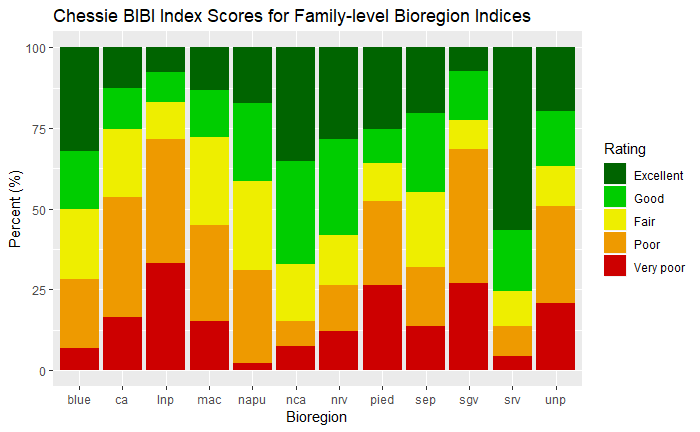

**6.3** Create a pie chart of the combined ratings from each bioregion using base R. Percentages of each rating category are hand-entered from *pie_total* into `slices`.

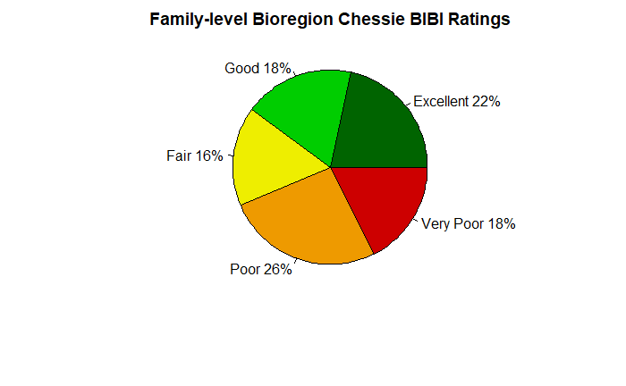